# Dynamic Linear Model using ggplot

Time Series

Represent Result of Dynamic Linear Model for Time Series Data in ggplot.

Yeongeun Jeon  
05-30-2020

- Data 출처 : [Data Mining for Business Analytics](https://www.dataminingbook.com/book/r-edition)에서 사용한 미국 철도 회사 “Amtrak”에서 수집한 1991년 1월~2004년 3월까지 매달 환승 고객 수

# **1. Time series data 불러오기**

```
pacman::p_load("data.table",
               "xts",
               "ggplot2",
               "colorspace") # color select


# Data 불러오기기

Amtrak.data <- fread(paste(getwd(),"Amtrak.csv", sep="/"))
```

```
# Create time series

ridership.ts <- ts(Amtrak.data$Ridership, start=c(1991,1), end=c(2004,3), freq=12)
train.ts     <- window(ridership.ts,start=c(1991,1), end=c(2001,3))
valid.ts     <- window(ridership.ts,start=c(2001,4))
nValid       <- length(valid.ts)
```

```
# Create Data.frame for ggplot
xts(ridership.ts, order = as.Date(ridership.ts) )
```

```
               [,1]
1991-01-01 1708.917
1991-02-01 1620.586
1991-03-01 1972.715
1991-04-01 1811.665
1991-05-01 1974.964
1991-06-01 1862.356
1991-07-01 1939.860
1991-08-01 2013.264
1991-09-01 1595.657
1991-10-01 1724.924
1991-11-01 1675.667
1991-12-01 1813.863
1992-01-01 1614.827
1992-02-01 1557.088
1992-03-01 1891.223
1992-04-01 1955.981
1992-05-01 1884.714
1992-06-01 1623.042
1992-07-01 1903.309
1992-08-01 1996.712
1992-09-01 1703.897
1992-10-01 1810.000
1992-11-01 1861.601
1992-12-01 1875.122
1993-01-01 1705.259
1993-02-01 1618.535
1993-03-01 1836.709
1993-04-01 1957.043
1993-05-01 1917.185
1993-06-01 1882.398
1993-07-01 1933.009
1993-08-01 1996.167
1993-09-01 1672.841
1993-10-01 1752.827
1993-11-01 1720.377
1993-12-01 1734.292
1994-01-01 1563.365
1994-02-01 1573.959
1994-03-01 1902.639
```

[output cut: 105 more lines]

```
2003-01-01 1778.033
2003-02-01 1749.489
2003-03-01 2066.466
2003-04-01 2098.899
2003-05-01 2104.911
2003-06-01 2129.671
2003-07-01 2223.349
2003-08-01 2174.360
2003-09-01 1931.406
2003-10-01 2121.470
2003-11-01 2076.054
2003-12-01 2140.677
2004-01-01 1831.508
2004-02-01 1838.006
2004-03-01 2132.446
```

```
ridership            <- as.data.frame(ridership.ts)
names(ridership)     <- "Observation"
ridership$Date       <- as.Date(ridership.ts)  # add Date column in last
cln                  <- ncol(ridership)
ridership            <- ridership[, c(cln, 1:(cln-1))]  # change the order of the column. That is first column "Date"
row.names(ridership) <- NULL
train                <- ridership[1:123,]
valid                <- ridership[-(1:123),]
nValid               <- nrow(valid)
```

- ggplot은 data.frame을 기반으로 하기 때문에 data.frame으로 바꿔줘야하며, filtering 이나 smooting은 시계열을 기반으로 해야해서 시계열도 따로 만들었다.

# **2. Dynamic linear model (DLM)**

## **2.1 모형 설정**

```
library(dlm)

model1 <- function(p){

   mod               <- dlmModPoly(2) +  # local trend linear
                        dlmModSeas(12)

   V(mod)            <- exp(p[1])
   diag(W(mod))[1:3] <- exp(p[2:4])

  return(mod)
}
```

- Dynamic linear model 에서 local trend linear + seasonality 모형으로 설정했다.

## **2.2 모수 추정**

```
mle1 <- dlmMLE(train.ts, parm=c(0.1,0.1,1,1), build=model1 )   # Estimation parameter through MLE. parameter=variance of error
ifelse(mle1$convergence==0, print("converge"), print("did not converge") ) # Check converge
```

```
[1] "converge"
```

```
[1] "converge"
```

```
modelfit1 <- model1(mle1$par)  # Fitting the DLM model
V(modelfit1)
```

```
        [,1]
[1,] 1413.91
```

```
W(modelfit1)
```

```
          [,1]      [,2]     [,3] [,4] [,5] [,6] [,7] [,8] [,9] [,10]
 [1,] 1143.988 0.0000000  0.00000    0    0    0    0    0    0     0
 [2,]    0.000 0.2040261  0.00000    0    0    0    0    0    0     0
 [3,]    0.000 0.0000000 14.47867    0    0    0    0    0    0     0
 [4,]    0.000 0.0000000  0.00000    0    0    0    0    0    0     0
 [5,]    0.000 0.0000000  0.00000    0    0    0    0    0    0     0
 [6,]    0.000 0.0000000  0.00000    0    0    0    0    0    0     0
 [7,]    0.000 0.0000000  0.00000    0    0    0    0    0    0     0
 [8,]    0.000 0.0000000  0.00000    0    0    0    0    0    0     0
 [9,]    0.000 0.0000000  0.00000    0    0    0    0    0    0     0
[10,]    0.000 0.0000000  0.00000    0    0    0    0    0    0     0
[11,]    0.000 0.0000000  0.00000    0    0    0    0    0    0     0
[12,]    0.000 0.0000000  0.00000    0    0    0    0    0    0     0
[13,]    0.000 0.0000000  0.00000    0    0    0    0    0    0     0
      [,11] [,12] [,13]
 [1,]     0     0     0
 [2,]     0     0     0
 [3,]     0     0     0
 [4,]     0     0     0
 [5,]     0     0     0
 [6,]     0     0     0
 [7,]     0     0     0
 [8,]     0     0     0
 [9,]     0     0     0
[10,]     0     0     0
[11,]     0     0     0
[12,]     0     0     0
[13,]     0     0     0
```

- MLE 방법으로 Train data에 대한 모수를 추정한다.이 때 모수는 error의 covariance의 diagonal이다.
- 모수의 수렴성을 확인하고 추정된 모수를 이용하여 DLM model을 적합하였다.

## **2.3 State 추정**

- Unobservable state를 추정하는 방법에는 Kalman filtering 방법과 Kalman smoothing 방법이 있다.

### **2.3.1 Kalman filtering**

- 과거와 현재 즉, 현재까지 관측된 상태를 이용하여 현재 상태를 추정하는 방법이다.

```
filtering <- dlmFilter(train.ts, modelfit1)
str(filtering,1)
```

```
List of 9
 $ y  : Time-Series [1:123] from 1991 to 2001: 1709 1621 1973 1812 1975 ...
 $ mod:List of 10
  ..- attr(*, "class")= chr "dlm"
 $ m  : Time-Series [1:124, 1:13] from 1991 to 2001: 0 263 1477 2060 2237 ...
 $ U.C:List of 124
 $ D.C: num [1:124, 1:13] 3162.3 26.6 23.4 21.4 19.3 ...
 $ a  : Time-Series [1:123, 1:13] from 1991 to 2001: 0 394 2049 2636 2683 ...
 $ U.R:List of 123
 $ D.R: num [1:123, 1:13] 10916 8163 5192 4498 4165 ...
 $ f  : Time-Series [1:123] from 1991 to 2001: 0 263 1954 2542 2578 ...
 - attr(*, "class")= chr "dlmFiltered"
```

- y : observation
- mod : model
- U.C/D.C : singular value decomposition of variance of the filtered distributions
- a : the mean of the predictive distributions
- U.R/D.R : singular value decomposition of variance of the predictive distributions
- f : one-step-ahead forecast

#### **Plot estimation for filtering**

##### **Fitted model**

```
filter <- data.frame(Date=train$Date, Observation=filtering$f) # Observation = Fitted filtering
```

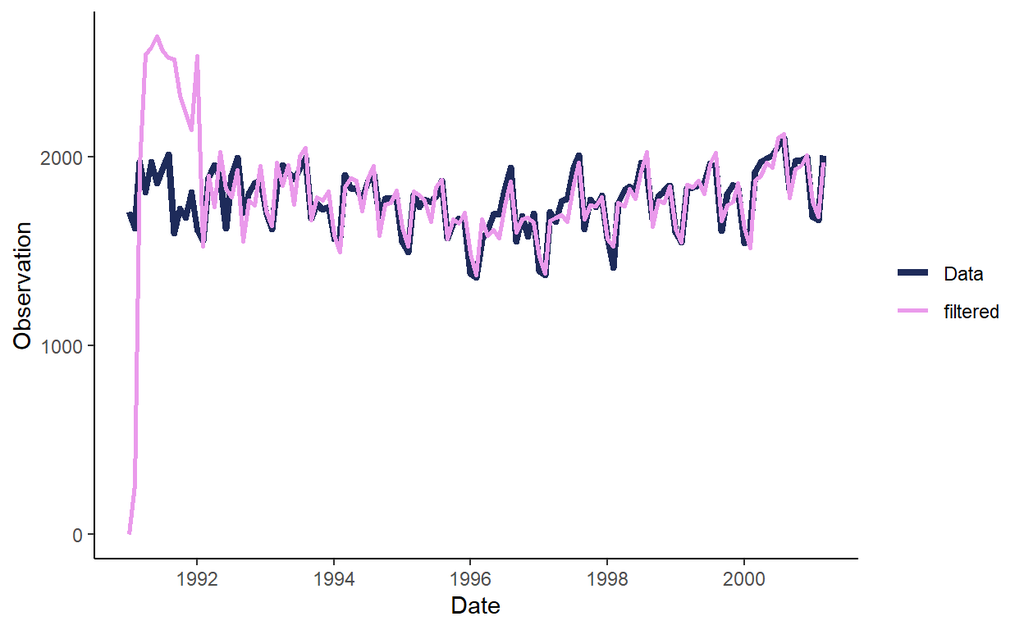

```
# train + filter data.frame

train_filter <- rbind(
  train,
  filter

)

train_filter$Group <- c(rep("Data",length(train.ts)), rep("filtered",length(train.ts)))

# pal <- choose_palette()
ggplot(train_filter, aes(x=Date, y=Observation, col=Group, size=Group))+geom_line()+
  scale_color_manual(values=c("#1E2B5A","#EA9AEB"))+
  scale_size_manual(values=c(1.5,1)) +
  theme_classic()+
  theme(legend.title = element_blank())
```

- ggplot을 사용하기 위하여 data.frame으로 바꿔줘야 한다.

##### **Filtering error**

```
cov.filter <- dlmSvd2var(filtering$U.C, filtering$D.C)   # covariance of state
sd.filter <- t(sapply(cov.filter, FUN=function(x) sqrt(diag(x))))   # standard deviation of state
```

```
cov.filter  # covariance of state for each observation
```

[output not shown]

[output cut: 5426 more lines]

```
sd.filter  # standard deviation of state for each observation
```

```
             [,1]        [,2]       [,3]       [,4]       [,5]
  [1,] 3162.27766 3162.277660 3162.27766 3162.27766 3162.27766
  [2,] 4113.87042 3038.220640 4113.98938 3038.22061 3038.22061
  [3,] 2625.42959 1801.015721 2625.26948 2047.23919 3031.36997
  [4,] 2284.37701 1318.892225 2284.30074 1615.49216 1865.51736
  [5,] 2119.56369 1008.582596 2119.53256 1455.99070 1334.54148
  [6,] 1997.11776  793.622816 1997.12254 1397.52159 1084.80240
  [7,] 1888.83047  640.132282 1888.86873 1364.35046  987.09583
  [8,] 1789.11461  527.659646 1789.18534 1332.98784  953.56773
  [9,] 1696.89263  443.175813 1696.99507 1298.41328  940.63900
 [10,] 1611.71799  378.236734 1611.85143 1260.75282  931.21763
 [11,] 1533.09138  327.270890 1533.25517 1221.15465  919.75126
 [12,] 1460.42870  286.524037 1460.62228 1180.68938  905.00273
 [13,] 1393.12141  253.409760 1393.34431 1140.13910  887.17753
 [14,]   44.33686   10.774087   42.98777   54.06646   52.38337
```

[output cut: 360 more lines]

```
filter$level      <-filtering$m[-1,1]
filter$level_sd   <- sd.filter[-1,1]
filter$slope      <- filtering$m[-1,2]
filter$slope_sd   <- sd.filter[-1,2]
filter$season1    <- filtering$m[-1,3]
filter$season1_sd <- sd.filter[-1,3]  # Seasonal represent 3~13 columns. However, just for Season1.
```

```
filter
```

```
          Date Observation     level   level_sd        slope
1   1991-01-01       0.000  262.9201 4113.87042 131.45255272
2   1991-02-01     262.920 1476.8170 2625.42959 571.74869261
3   1991-03-01    1953.806 2060.3500 2284.37701 576.13321930
4   1991-04-01    2542.089 2237.2100 2119.56369 446.14979550
5   1991-05-01    2578.135 2385.8677 1997.11776 362.60860175
6   1991-06-01    2636.291 2401.0946 1888.83047 278.08632437
7   1991-07-01    2559.954 2424.6579 1789.11461 223.86256634
8   1991-08-01    2524.776 2455.6739 1696.89263 187.47536594
9   1991-09-01    2516.373 2322.8861 1611.71799 133.37877892
10  1991-10-01    2324.983 2262.8372 1533.09138 103.85035440
11  1991-11-01    2232.946 2199.5074 1460.42870  80.59240254
12  1991-12-01    2144.421 2187.4420 1393.12141  68.76012370
13  1992-01-01    2533.874 1758.4610   44.33686  -7.79796175
14  1992-02-01    1526.730 1764.1211   43.45089  -6.52855213
```

[output cut: 233 more lines]

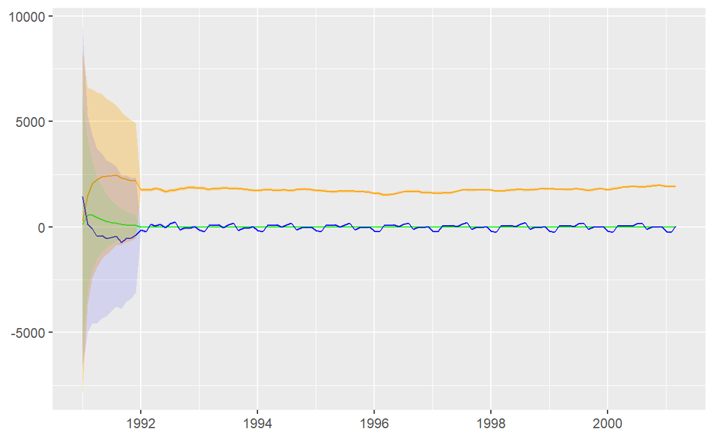

```
ggplot(filter, aes(x = Date, y = level)) +  geom_line(color = "orange") +
  geom_line(aes(y = slope),color = "green") + geom_line(aes(y = season1),color = "blue") +
  geom_ribbon(aes(ymin = level - 1.96 * level_sd, ymax = level + 1.96 * level_sd), alpha = 0.3, fill = "orange") +
  geom_ribbon(aes(ymin = slope - 1.96 * slope_sd, ymax = slope + 1.96 * slope_sd), alpha = 0.1, fill = "green") +
  geom_ribbon(aes(ymin = season1 - 1.96 * season1_sd, ymax = season1 + 1.96 * season1_sd), alpha = 0.1, fill = "blue") +
  theme(axis.title = element_blank())
```

### **2.3.1 Kalman smoothing**

- 주어진 관측된 값들을 이용하여 state의 과거값을 추정한다.

```
smoothing <- dlmSmooth(filtering)
str(smoothing,1)
```

```
List of 3
 $ s  : Time-Series [1:124, 1:13] from 1991 to 2001: 1900 1899 1885 1878 1835 ...
 $ U.S:List of 124
 $ D.S: num [1:124, 1:13] 46.6 32.5 29.1 28.3 28 ...
```

- s : the mean of the smoothing distributions
- U.S/D.S : singular value decomposition of variance of the smoothing distributions

#### **Plot estimation for smoothing**

##### **Fitted model**

```
theta         <- modelfit1$GG%*%t(smoothing$s[1:length(train.ts),])  #s0-s[t] : total t+1
fitted_smooth <- data.frame(Date=train$Date, Observation=as.numeric(modelfit1$FF%*%theta))
```

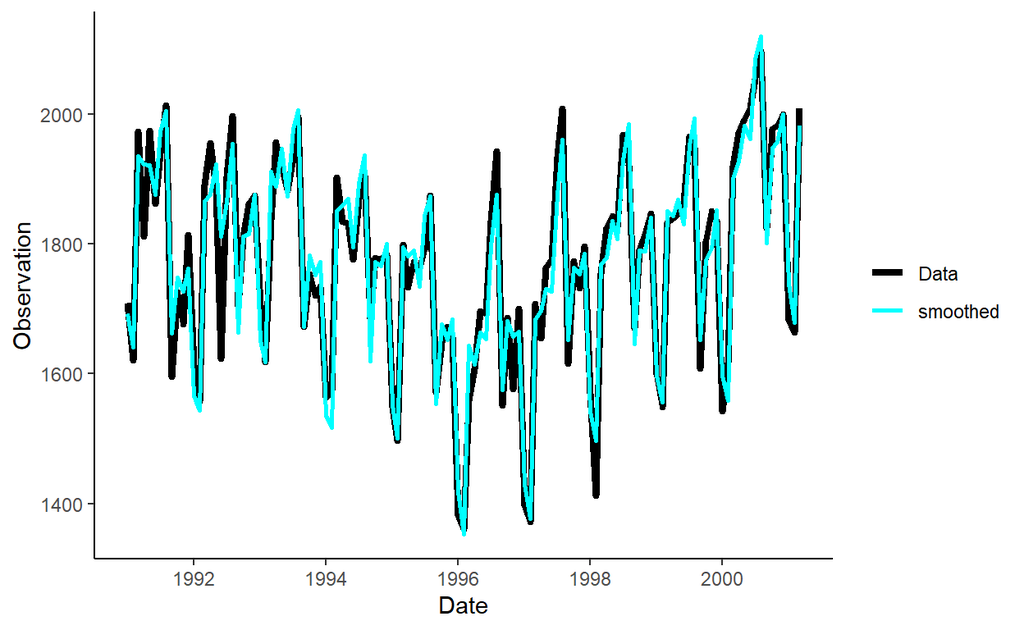

```
# train + smooth data.frame

train_smooth <- rbind(
  train,
  fitted_smooth

)

train_smooth$Group <- c(rep("Data",length(train.ts)), rep("smoothed",length(train.ts)))

ggplot(train_smooth, aes(x=Date, y=Observation, col=Group, size=Group))+geom_line()+
  scale_color_manual(values = c("black", "cyan")) +
  scale_size_manual(values=c(1.5,1)) +
  theme_classic()+
  theme(legend.title = element_blank())
```

- ggplot을 사용하기 위하여 data.frame으로 바꿔줘야 한다.

##### **Smoothing error**

```
cov.smooth <- dlmSvd2var(smoothing$U.S, smoothing$D.S)             # covariance of state for each observation
sd.smooth <- t(sapply(cov.smooth, FUN=function(x) sqrt(diag(x))))  # standard deviation of state for each observation
```

```
cov.smooth
```

[output not shown]

[output cut: 5440 more lines]

```
sd.smooth
```

```
           [,1]     [,2]     [,3]     [,4]     [,5]     [,6]     [,7]
  [1,] 46.39873 4.100858 18.51748 18.49698 18.50086 18.50424 18.50545
  [2,] 31.07455 4.075906 17.70304 18.51748 18.49698 18.50086 18.50424
  [3,] 26.81930 4.051190 17.50305 17.70304 18.51748 18.49698 18.50086
  [4,] 25.82207 4.026887 17.48086 17.50305 17.70304 18.51748 18.49698
  [5,] 25.60044 4.003076 17.66852 17.48086 17.50305 17.70304 18.51748
  [6,] 25.55309 3.979786 17.69357 17.66852 17.48086 17.50305 17.70304
  [7,] 25.54466 3.957026 17.70080 17.69357 17.66852 17.48086 17.50305
  [8,] 25.54462 3.934797 17.70457 17.70080 17.69357 17.66852 17.48086
  [9,] 25.54528 3.913100 17.70582 17.70457 17.70080 17.69357 17.66852
 [10,] 25.54464 3.891930 17.70456 17.70582 17.70457 17.70080 17.69357
 [11,] 25.54234 3.871285 17.70103 17.70456 17.70582 17.70457 17.70080
 [12,] 25.53842 3.851161 17.69697 17.70103 17.70456 17.70582 17.70457
 [13,] 25.53177 3.831555 17.71309 17.69697 17.70103 17.70456 17.70582
 [14,] 25.49711 3.812471 17.04370 17.71309 17.69697 17.70103 17.70456
```

[output cut: 235 more lines]

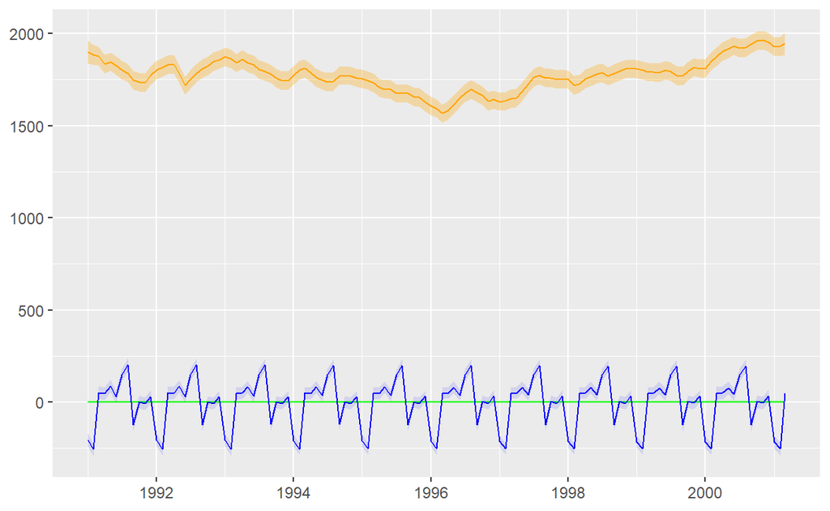

```
fitted_smooth$level      <-smoothing$s[-1,1]
fitted_smooth$level_sd   <- sd.smooth[-1,1]
fitted_smooth$slope      <- smoothing$s[-1,2]
fitted_smooth$slope_sd   <- sd.smooth[-1,2]
fitted_smooth$season1    <- smoothing$s[-1,3]
fitted_smooth$season1_sd <- sd.smooth[-1,3]  # Seasonal represent 3~13 columns. However, just for Season1.


# Smoothing estimation error

ggplot(fitted_smooth, aes(x = Date, y = level)) +  geom_line(color = "orange") +
  geom_line(aes(y = slope),color = "green") + geom_line(aes(y = season1),color = "blue") +
  geom_ribbon(aes(ymin = level - 1.96 * level_sd, ymax = level + 1.96 * level_sd), alpha = 0.3, fill = "orange") +
  geom_ribbon(aes(ymin = slope - 1.96 * slope_sd, ymax = slope + 1.96 * slope_sd), alpha = 0.1, fill = "green") +
  geom_ribbon(aes(ymin = season1 - 1.96 * season1_sd, ymax = season1 + 1.96 * season1_sd), alpha = 0.1, fill = "blue") +
  theme(axis.title = element_blank())
```

## **2.4 예측**

```
forecast <- dlmForecast(filtering, nAhead = nValid)  # Forecast(filtering model)
```

- a : the means of future state
- R : the variance of future state
- f : the means of future observations
- Q : the variance of future observations

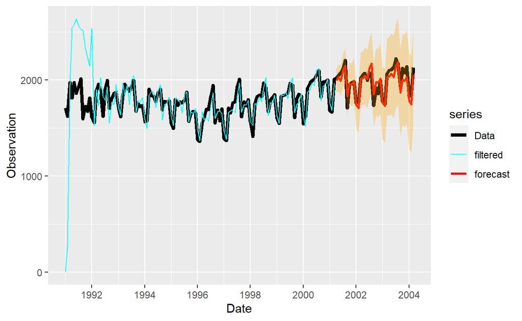

```
# data.frame
x <- index(ridership.ts)

forecast_df <- rbind(

  data.frame(Date=x, Observation=as.numeric(ridership$Observation), sd=0, series="Data"),
  data.frame(Date=x[1:123], Observation=filtering$f, sd=0, series="filtered"), # Filtered
  data.frame(Date=x[-(1:123)], Observation=c(forecast$f), sd=sqrt(unlist(forecast$Q)), series="forecast")                            # Forecast

)


ggplot(forecast_df, aes(x = Date, y = Observation,col=series, size=series))  +  geom_line() +
scale_color_manual(values = c("black", "cyan", "red")) +
scale_size_manual(values = c(1.5,0.5,1)) +
geom_ribbon(aes(ymin = Observation - 1.96 * sd, ymax = Observation + 1.96 * sd), alpha = 0.3, fill="orange", show.legend = FALSE, colour=FALSE) +
scale_x_continuous(breaks = seq(min(x)+1, max(x), by = 2))
```